# KMmeans Clustering Algorithm

#### The simplest algorithm used for the clustering ,

## Intuition

#### The points are nearer to the center of their clusters

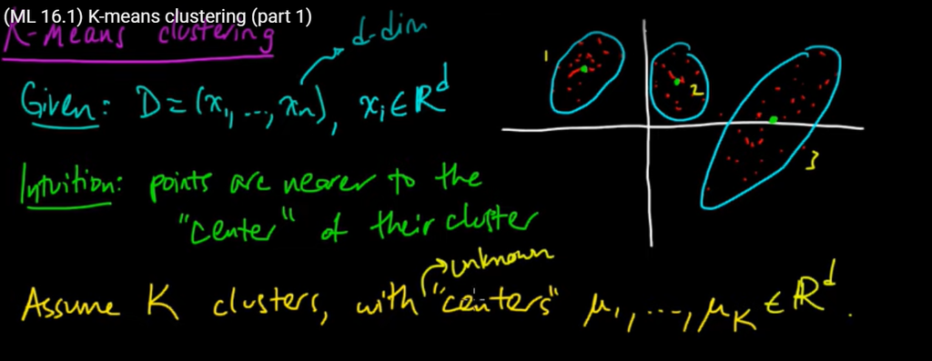

### So let's now see how this works

#### 1) Let's assume that the points plottted and mew be their centres

#### let a be assignments and u (mew ) be the centres or labels that we are yet to determine

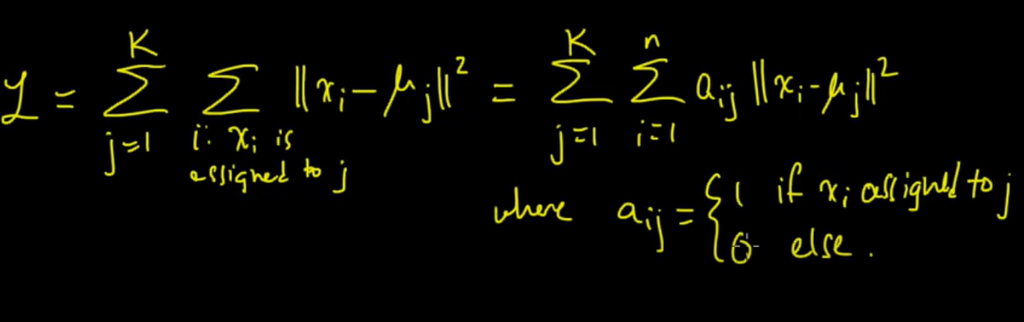

### So the equation that needs to be minimise is given above ,

#### here i = (1 to n) is number of points or assignments

#### here j = (1 to K) is the number of labels or centres

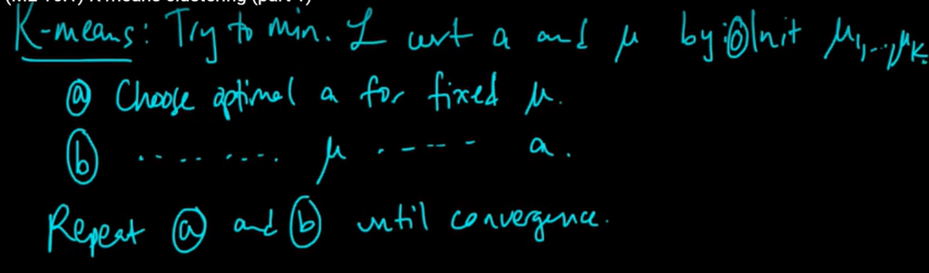

## How can we minimise this equation ?

### we minimise the equation by following the below steps

#### a) Choose optimal assignments (a) for a fixed centre (u) mew

#### b) Choose optimal center (u) for fixed assignments (a)

#### Repeat the steps until convergence

### a) Choose optimal assignments (a) for a fixed centre (u) mew

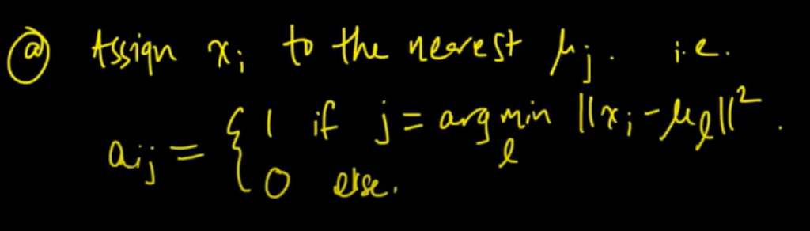

### step a is easily achieved by assigning the points to their nearest centres , note that now the centres were randomnly chosen in this step

### b) Choose optimal center (u) for fixed assignments (a)

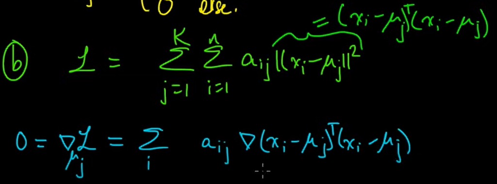

### 1) so we now write the eucledian distance in the equation L as a dot product of two matrices

### 2 ) In order to minimise L let's take differential at particular center (j) , and since we now take only one jth center , the resulting equation has only one summation on i = (1...n)

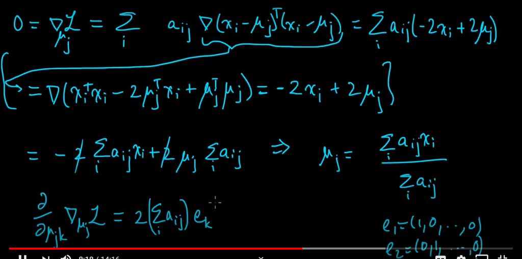

### 3) replacing with vector multiplication we get -2x+2u

### 4) thus we can get an equation for u now which depends assignments by equating L to zero

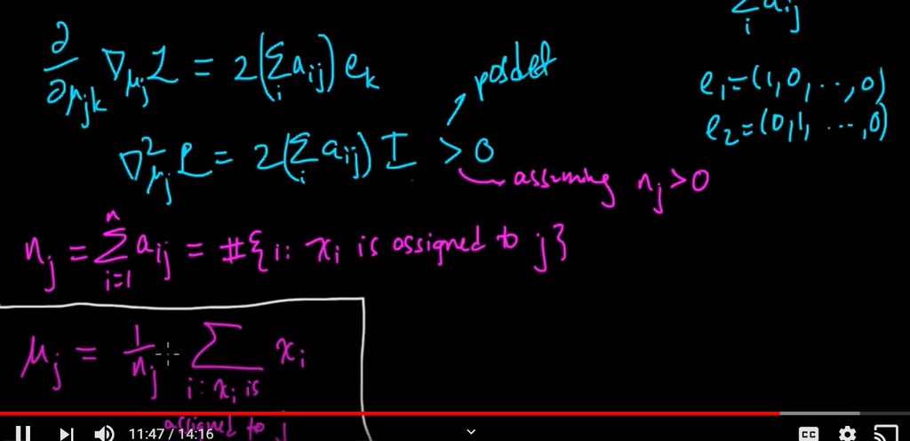

### 6) substituiting with the number of elements (n) to the equation we finally get that center (u) lies on the mean of all the assignments to j

## So now we can simply follow below steps for kmeans

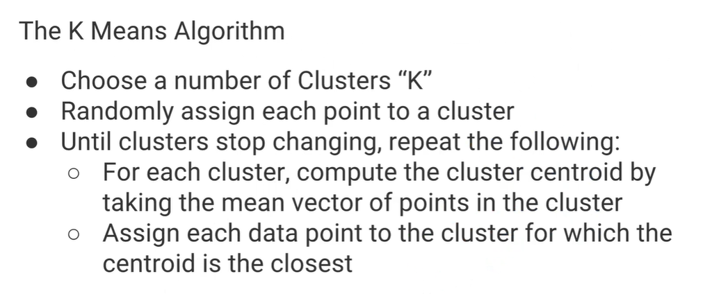

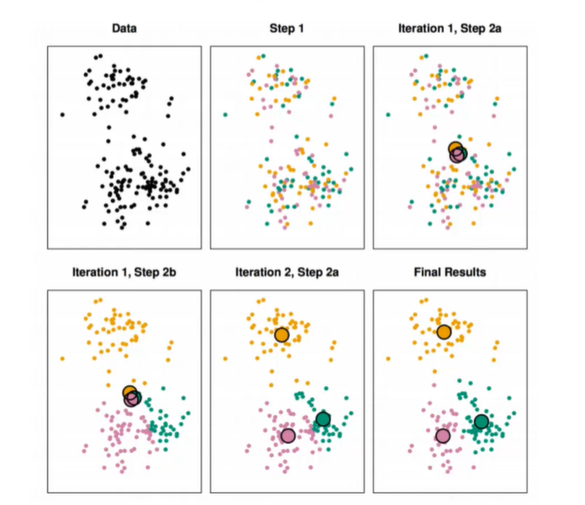